# 03SemanaProgramacion_110521

## Programación - Ciencia de datos - Condicionales - 11/052021

### Estructura del programa

```
Un programa python está formado por instrucciones que acaban en un caracter de "salto de línea".

El punto y coma “;” se puede usar para separar varias sentencias en una misma línea, pero no se aconseja su uso.

Una línea empiza en la primera posición, si tenemos instrucciones dentro de un bloque de una estrucura de control de flujo habra que hacer una identación.

La identación se puede hacer con espacios y tabulaciones pero ambos tipos no se pueden mezclar. Se recomienda usar 4 espacios.

La barra invertida "\" al final de línea se emplea para dividir una línea muy larga en dos o más líneas.

Las expresiones entre paréntesis "()", llaves "{}" y corchetes "[]" separadas por comas "," se pueden escribir ocupando varias líneas.

Cuando el bloque a sangrar sólo ocupa una línea ésta puede escribirse después de los dos punto.
```

### Comentarios

Se utiliza el caracter # para indicar los comentarios.

### Palabras reservadas

False class finally is return None continue for lambda try True def from nonlocal while and del global not with as elif if or yield assert else import pass break except in raise

### Ejemplo

```python
# Sangrado con 4 espacios

edad = 23
if edad >=18:
    print('Es mayor de edad')
else:
    print('Es menor de edad')

# Cada bloque de instrucciones dentro de una estructura de control
# debe estar tabulada

#num=0
if num >=0:
    while num<10:
        print (num)
        num = num +1

# El punto y coma “;” se puede usar para separar varias sentencias
# en una misma línea, pero no se aconseja su uso.

edad = 15; print(edad)

# Cuando el bloque a sangrar sólo ocupa una línea ésta puede
# escribirse después de los dos puntos:

#azul=1
if azul: print('Cielo')

# Las expresiones entre paréntesis, llaves o corchetes pueden
# ocupar varias líneas:

dias = ['lunes', 'martes', 'miércoles', 'jueves',
        'viernes', 'sábado', 'domingo']
```

```
Es mayor de edad
15
Cielo
```

### Repositorios de ejemplos de códigos y ejercicios.

https://github.com/gigantemental/Python-Ejercicios

https://github.com/ecubillanleon/Python

https://github.com/carlosgbr/python0

https://github.com/MiguelDMonzon/Ejercicios-basicos-Python

### Veamos como bajar un repo a nuestro equipo.

[figure not shown]

https://git-scm.com/downloads

### Tutorial

https://www.geeksforgeeks.org/working-on-git-for-gui/

[figure not shown]

[figure not shown]

[figure not shown]

[figure not shown]

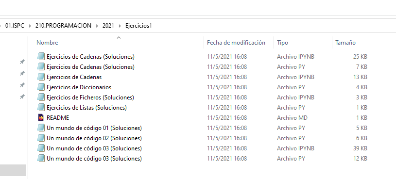

### Ejercicio 1

Escribir un programa que muestre por pantalla la cadena ¡Hola Mundo!.

### Ejercicio 2

Escribir un programa que almacene la cadena ¡Hola Mundo! en una variable y luego muestre por pantalla el contenido de la variable.

### Ejercicio 4

Escribir un programa que muestre por pantalla el resultado de la siguiente operación aritmética: 3 mas 2 dividido 2 por 5, todo al cuadrado.

$$ \big(\frac{3+2}{2*5}\big)^2 $$

### Ejercicio 5

Escribir un programa que pregunte al usuario por el número de horas trabajadas y el coste por hora. Después debe mostrar por pantalla la paga que le corresponde.

### Ejercicio 6

Escribir un programa que lea un entero positivo, n, introducido por el usuario y después muestre en pantalla la suma de todos los enteros desde 1 hasta n. La suma de los primeros enteros positivos puede ser calculada de la siguiente forma:

$$ suma = \frac{n*(n+1)}{2} $$